# 11-Arima

```python
import numpy as np
import matplotlib.pyplot as plt
import pandas as pd
import seaborn as sns
# !pip install pmdarima
import pmdarima
```

```python
# We open the data and make the ticker as the index
df = pd.read_csv('Nikkei-2010-2012.csv',index_col="Ticker")
df.head()
```

| Ticker | 2010-01-04 | 2010-01-05 | 2010-01-06 | 2010-01-07 | 2010-01-08 | 2010-01-12 | 2010-01-13 | 2010-01-14 | 2010-01-15 | 2010-01-18 | ... | 2012-12-14 | 2012-12-17 | 2012-12-18 | 2012-12-19 | 2012-12-20 | 2012-12-21 | 2012-12-25 | 2012-12-26 | 2012-12-27 | 2012-12-28 |
| --- | --- | --- | --- | --- | --- | --- | --- | --- | --- | --- | --- | --- | --- | --- | --- | --- | --- | --- | --- | --- | --- |
| 4151.t | 999.0 | 989.0 | 1003.0 | 984.0 | 991.0 | 984.0 | 985.0 | 990.0 | 989.0 | 975.0 | ... | 845.0 | 848.0 | 852.0 | 861.0 | 850.0 | 852.0 | 856.0 | 850.0 | 851.0 | 849.0 |
| 4502.t | 3850.0 | 3870.0 | 3870.0 | 3930.0 | 3900.0 | 3940.0 | 3930.0 | 3970.0 | 3970.0 | 3945.0 | ... | 3805.0 | 3835.0 | 3845.0 | 3870.0 | 3875.0 | 3865.0 | 3865.0 | 3865.0 | 3860.0 | 3855.0 |
| 4503.t | 694.0 | 700.0 | 700.0 | 700.0 | 702.0 | 700.0 | 696.0 | 704.0 | 702.0 | 697.0 | ... | 797.0 | 800.0 | 809.0 | 812.0 | 802.0 | 792.0 | 797.0 | 798.0 | 780.0 | 775.0 |
| 4506.t | 979.0 | 984.0 | 991.0 | 982.0 | 981.0 | 977.0 | 979.0 | 982.0 | 980.0 | 965.0 | ... | 999.0 | 1013.0 | 1019.0 | 1026.0 | 1012.0 | 1010.0 | 1021.0 | 1032.0 | 1033.0 | 1035.0 |
| 4507.t | 2003.0 | 2007.0 | 2007.0 | 1957.0 | 1930.0 | 1931.0 | 1904.0 | 1968.0 | 1957.0 | 1926.0 | ... | 1349.0 | 1382.0 | 1443.0 | 1462.0 | 1461.0 | 1457.0 | 1454.0 | 1469.0 | 1479.0 | 1437.0 |

5 rows × 736 columns

We select one of the time series to which we ewill apply arima

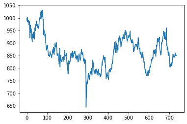

```python
series = df.iloc[0,:]
plt.plot(np.array(series))
```

Plot the 7 day rolling mean and rolling std

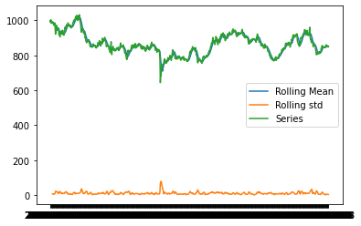

```python
plt.plot(series.rolling(7).mean(),label="Rolling Mean")
plt.plot(series.rolling(7).std(),label="Rolling std")
plt.plot(series,label="Series")
plt.legend()
```

We calculate the stationarity of the time series using the adfuller function

```python
import statsmodels.tsa.stattools as st
adf = st.adfuller(x=series, regression="ct", maxlag=12)
print("adf:", adf[0], "adf_pvalue:", adf[1])
```

```
adf: -3.160714505347424 adf_pvalue: 0.09251781892459549
```

The fact that the pvalue is so much bigger than 0 indicates that teh time series is not stationary

Now we take the returns of the time series

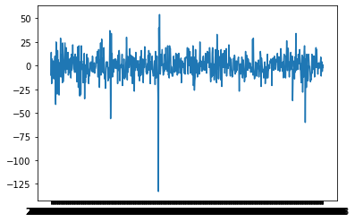

```python
series_diff = series.diff().dropna()
plt.plot(series_diff)
```

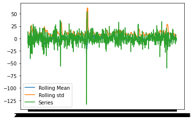

```python
plt.plot(series_diff.rolling(7).mean(),label="Rolling Mean")
plt.plot(series_diff.rolling(7).std(),label="Rolling std")
plt.plot(series_diff,label="Series")
plt.legend()
```

Again calculate the adfuller function

```python
adf = st.adfuller(x=series_diff, regression="ct", maxlag=12)
print("adf:", adf[0], "adf_pvalue:", adf[1])
```

```
adf: -20.565760159335618 adf_pvalue: 0.0
```

The result is now $0$, indicating stationarity